# Predicting Marital Status - Cleaning Data

Rachel Kalusniak

2023-04-24

```r
library(dplyr)
library(lubridate)
library(tidyr)
library(stringr)
library(skimr)
```

## Accessing the Data

Accessing the data for this project was more complicated that I originally expected. The initial download of data I accessed was more than 7GB and crashed both my Rstudio and excel. I eventually had to redownload Rstudio to clear the output.

I then found [NSLY Investigator](https://www.nlsinfo.org/investigator), which allowed me to select just the variables I wanted out of the about 60,000 available in the study. In my selection, I focused on factors I hypothesized could impact marital status, including education, income, family background, and health. Most of the data is in wide format, with each response year getting its own variable. I selected more variables knowing that I could filter more during the data processing as I needed.

When I opened CSV file for the Investigator site, I was originally very overwhelmed. The data lacked understandable variable names, and missing values needed to be recoded from negative numbers to `NA`. I briefly considered finding a new cleaner data set with this setback.

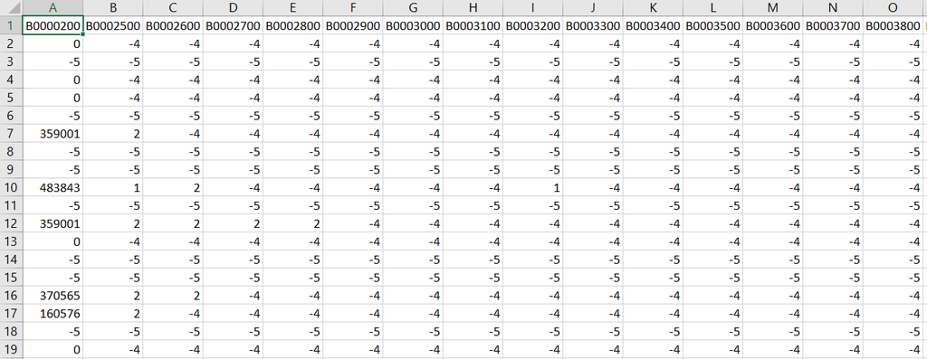

Instead, I did a bit more investigation and discovered that the Investigator site will provide an R-script file to convert the negative numbers to `NA` and rename the variables. The script also can change all the variables to categorical factors, if desired. I decided to do the factor conversion separately because I wanted to keep some variables like income and marriage date continuous so I could do further manipulations. The only change I had to make to the Rscript files was adding a line at the end to save the output as an RDS file that I could then read into this document to read and manipulate.

## Cleaning the Data

Much of this project embodies the idea that ’80% of a data scientist time is spent just getting a clean data set. I organized by data cleaning by topic, so I could easily track my progress. Since all my manipulations were on the original data set, this structure also prevented needing to rerun all the cleaning steps every time.

My first step is to read in the RDS files created in the Rscripts mentioned above.

Through the data cleaning process I realized I only had the individual’s current marital status. This can account for individuals that never marry, but it doesn’t account for marriage failures. If an individual gets divorced and remarries it will not reflect here. Therefore, I found another variable that details the status of subject’s first marriage. The data set includes an ID variable, so it is simple to join the data files into a single set.

Given that I started with 200 variables, I had to create a list of notes, so I could track the variables I already cleaned and the variables I still wanted to manipulate. Therefore, I wrote the variables names to a csv file and re-saved it as mynotes.xlsx, so I could use this file for tracking without the script accidentally overwriting it.

```r
#Read in data files
nlsy97 <- readRDS('Data/new_data.Rds')
divorce <- readRDS('Data/divorce.Rds')

#Add ending of first marriage to data
nlsy97 <- nlsy97 %>%
  inner_join(select(divorce, PUBID_1997, CVC_FIRST_MARRY_END_XRND), by = 'PUBID_1997')

#Create export of variable names
#write.csv(names(nlsy97), file = "data/varnames.csv")

#Clean environment by removing divorce data
rm(divorce)
```

### ID Variables

I started the data cleaning by looking at the five ID variables for sex, race/ethnicity, birth date, and sample type.This data set over samples certain populations and uses weights to adjust to the demographics on the United States. For the sake of simplicity, I did not consider the weights in this analysis. However, this could be an area for future research

Another necessary simplification was creating birth dates. The data only provides the year and month of the subjects birth for their anonymity. To compute a birth date for later age variables, I assume everyone was born on the first of the month. The variation is age from this assumption is minimal

I also simplfy variable names and drop any variables that are not longer necessary.

```r
nlsy97 <- nlsy97 %>%
  rename(RACE = KEY_RACE_ETHNICITY_1997) %>%
  mutate(BDAY = as.Date(paste(KEY_BDATE_Y_1997, '-', KEY_BDATE_M_1997, '-01', sep = '')),
         FEMALE = as.factor(if_else(KEY_SEX_1997 == 2, 1, 0))) %>% # Create bianary as factor
  select(-starts_with('KEY'), -CV_SAMPLE_TYPE_1997)

#Labels for race factor variable
RACE_ETH <- c('black', 'hispanic', 'mixed-race', 'non-black & non-hispanic')

#Function to convert a variable to a factor and add labels
  #Also used later in the education section
factorlevels <- function(df, variable, label) {
  df[[variable]] <- factor(df[[variable]], levels = sort(unique(df[[variable]])), labels = label)
  df
}

#Convert race to factor and add labels
nlsy97 <- factorlevels(nlsy97, 'RACE', RACE_ETH)
```

### Income Variables

The income section is the first time I encounter the issue of the wide time-series data. The surveyor’s slightly changed the question’s wording over the 20+ year span, so there are different variables names. For this project, I do not care about how the participants income changed overtime. I am looking at if poverty or wealth affects their decision to marry. At the beginning of the survey participants were 12 to 16 years old. Therefore, I decided to target the time-series variables in 1997, 2008, and 2019. These years will examine they household income as a teenager, young adult, and middle aged. This method might give a slight advantage to older survey participants because they have more years of experience. A more complex analysis could examine income at a specific age or at the time of marriage.

```r
nlsy97 <- nlsy97 %>%
  #Simplify variable names
  rename(INCOME_1997 =  CV_INCOME_GROSS_YR_1997,
         INCOME_2008 = CV_INCOME_FAMILY_2008,
         INCOME_2019 = CV_INCOME_FAMILY_2019) %>%
  #Drop all other income variables
  select(-starts_with('CV_INCOME'))
```

### Family Variables

```r
nlsy97 <- nlsy97 %>%
  rename(HHSIZE_1998 = CV_HH_SIZE_1998) %>%
  mutate(BOTHPARENTS_1997 = as.factor(if_else(CV_YTH_REL_HH_AGE_12_1997 == 1, 1, 0))) %>%
  #Drop variables no longer required
  select(-CV_HH_INCOME_SOURCE_1997, -CV_YTH_REL_HH_AGE_12_1997)
```

### Health Variables

Next, I considered variables relating to the participants health. The hypothesis is partners will be more attached to subjects that are healthy or confident in their own body. Therefore, these individuals are more likely to get and stay married. There are three factor variables related to health: overall health, perception of weight, and desired change in weight. The survey stops collection the weight perception and desired change in 2011, so it is not available for the most recent data. I chose to focus on the individuals age as a young adult in 2008 because most participants probably reached their maximum height at this age.

```r
nlsy97 <- nlsy97 %>%
  #Rename variables for easier understanding
  rename(HEALTH_1997 = 'YHEA-100_1997',
         HEALTH_2008 = 'YHEA-100_2008',
         HEALTH_2019 = 'YHEA-100_2019',
         WEIGHT_1997 = 'YHEA-2200_1997',
         WEIGHT_2008 = 'YSAQ-000B_2008',
         WEIGHT_2019 = 'YHEA-SAQ-000B_2019',
         WEIGHTPRECEP_1997 = 'YSAQ-373_1997',
         WEIGHTPRECEP_2008 = 'YSAQ-373_2008',
         WEIGHTCHANGE_1997 = 'YSAQ-374_1997',
         WEIGHTCHANGE_2008 = 'YSAQ-374_2008',
         HEIGHTFT_2008 = 'YSAQ-000A000001_2008',
         HEIGHTINONLY_2008 = 'YSAQ-000A000002_2008') %>%
  #Convert to total height in inches
  mutate(HEIGHTIN_2008 = HEIGHTINONLY_2008 + HEIGHTFT_2008 * 12) %>%
  #Drop extra variables
  select(-starts_with('Y'), -HEIGHTFT_2008, -HEIGHTINONLY_2008, -'PC9-001_1997')

#Adding labels
HEALTH <- c('excellent', 'very good', 'good', 'fair', 'poor')
WEIGHTPRECEP <- c('very under', 'slightly under', 'about right', 'slightly over', 'very over')
WEIGHTCHANGE <- c('lose', 'gain', 'stay same', 'nothing')


for (i in 1:7) {
  health_labels <- c('HEALTH', 'WEIGHTPRECEP', 'WEIGHTCHANGE')
  years <- c('1997', '2008', '2019')
  health_varslist <- as.vector(outer(health_labels, years, paste, sep = '_'))
  nlsy97 <- factorlevels(nlsy97, health_varslist[i], eval(parse(text = rep(health_labels, 3)[i])))
}
```

### Education Variables

I then wanted to look a academic achievement. I hypothesize that partners find intelligence attractive, so those with higher test scores or degrees are more likely to get and stay married.

I originally wanted to consider ACT and SAT score and transcript results as measures of intelligence. However, I found that the only about one-fourth of survey participants took the test and the transcript structure made it difficult to work with. Instead, the set provides the percentile ASVAB scores for most of the subjects.

The interactions between my hypothesis and degree level is unclear in the research. [This article](https://www.pewresearch.org/short-reads/2015/12/04/education-and-marriage/) from the Pew Research Center shows that educated women are more likely to stay in lasting marriages. However, other sources show education increases the probability that individuals never marry.

The data provides degree achievement by showing the month completed counting from January 1980. if the individual never achieved the degree, the variable shows `NA`. However, I want to look at degree status as a binary variable for this study. The date of completion does not matter. Therefore, I created a function to recode the degrees to a binary value and simplify the variable name. According to the code book, there are less than 200 invalid skips for these variable. This detail was lost in the original Rscript files. However, I believe the simplification that these individuals do not have a degree is fair.

```r
nlsy97 <- nlsy97 %>%
  #Simplify variable names
  rename(ASVAB = ASVAB_MATH_VERBAL_SCORE_PCT_1999,
         GRADESREPEAT = CVC_GRADES_REPEAT_EVER_2007_XRND,
         GRADESSKIP = CVC_GRADE_SKIPPED_EVER_2007_XRND,
         HIGHGRADE = CVC_HGC_EVER_XRND)

#Manipulate degree variables
MakeBinary <- function(df, variable){
  #Convert to binary
  df[[variable]][df[[variable]] >= 0] <- 1
  df[[variable]][is.na(df[[variable]])] <- 0
  #Change to factor
  df[[variable]] <- as.factor(df[[variable]])
  #Simplify variable name
  new_var_name <- strsplit(variable, '_')[[1]][2]
  rename(df, setNames(variable, new_var_name))
  }

#Create a list of education degree variables of interest
edu_varlist <- c('CVC_GED_XRND', 'CVC_HS_DIPLOMA_XRND', 'CVC_AA_DEGREE_XRND', 'CVC_BA_DEGREE_XRND',
                 'CVC_PROF_DEGREE_XRND', 'CVC_PHD_DEGREE_XRND', 'CVC_MA_DEGREE_XRND')

#Perform conversion
for (i in 1:7) {
  nlsy97 <- MakeBinary(nlsy97, edu_varlist[i])
}

#Drop extra variables
nlsy97 <-  nlsy97 %>%
  select(-matches(c('ACT', 'SAT', 'DEGREE')), -starts_with(c('TRAN', 'PSTRAN', 'CVC_HS')),
         -CVC_SCH_ATTEND_EVER_XRND)
```

### Work Variables

Then, I wanted to consider if an individuals work status. The hypothesis in workaholics and people without jobs are less likely to marry because they are not attractive to partners. This indicator may need to be squared in the model.

```r
nlsy97 <- nlsy97 %>%
  rename(WKSWK_ADULT = CVC_WKSWK_ADULT2_ALL_XRND) %>%
  select(-matches(c('CVC_WKSWK', 'JOB')))
```

### Marriage Variables

This provides two possible hypotheses to test. First, people who cohabitation before marriage are less likely to get married. Secondly, people who life together are more likely to get married.

```r
nlsy97 <- nlsy97 %>%

  mutate(
         #Compute date of first marriage and cohabitation
         MARRYDATE = ymd(19800101) + CVC_FIRST_MARRY_MONTH_XRND * 365/12,
         COHABDATE = ymd(19800101) + CVC_FIRST_COHAB_MONTH_XRND * 365/12,

         #Age of first marriage and first cohabitation. Age of cohabitation is only valid if before first marriage
         MARRYAGE = time_length(difftime(MARRYDATE, BDAY), "years"),
         COHABAGE = if_else(COHABDATE > MARRYDATE & !is.na(MARRYDATE), NA, time_length(difftime(COHABDATE, BDAY), "years")),

         #Binary for if cohabitation before their first marriage
         COHAB_PREMARRY = case_when(MARRYDATE > 0 & is.na(COHABDATE) ~ 0,
                                    COHABDATE < MARRYDATE & !is.na(COHABDATE) & !is.na(MARRYDATE) ~ 1,
                                    COHABDATE > MARRYDATE & !is.na(COHABDATE) & !is.na(MARRYDATE) ~ 0,
                                    COHABDATE > 0 & is.na(MARRYDATE) ~ 1,
                                    .default = 0),

         #Binary for if their first marriage fails
          #Show 1 if marriage ends in divorce
          #Show 0 if the marriage end in death of the spouse, annulment, or doesn't not end
          FAILMARRY = case_when(
           CVC_FIRST_MARRY_END_XRND == 1 & MARRYDATE > 0 ~ 1,
           (CVC_FIRST_MARRY_END_XRND != 1 | is.na(CVC_FIRST_MARRY_END_XRND))  & MARRYDATE > 0 ~ 0),

         #Binary for individuals that never married
         NEVERMARRY = case_when(CV_MARSTAT_COLLAPSED_2019 == 0 & is.na(MARRYAGE)  ~ 1,
                                CV_MARSTAT_COLLAPSED_2019 > 0  ~ 0)) %>%

  #Turn new binary variables into factors
  mutate(across(c(NEVERMARRY, COHAB_PREMARRY, FAILMARRY), factor)) %>%

  #Drop row the have problematic marriage data
  filter(is.na(MAR_IMPUTE_FIRST_MARRY_XRND)) %>%

  #Drop extra variables
  select(-starts_with(c('CV', 'MAR_IMPUTE')), -COHABDATE, -MARRYDATE)
```

## Summary

```r
str(nlsy97)
```

```
## 'data.frame':    8832 obs. of  37 variables:
##  $ PUBID_1997       : int  1 2 3 4 5 6 7 8 9 10 ...
##  $ HEALTH_1997      : Factor w/ 5 levels "excellent","very good",..: 1 1 2 4 1 4 1 1 1 2 ...
##  $ WEIGHT_1997      : int  145 135 98 186 135 156 188 135 160 85 ...
##  $ WEIGHTPRECEP_1997: Factor w/ 5 levels "very under","slightly under",..: 4 3 2 4 4 3 4 3 3 2 ...
##  $ WEIGHTCHANGE_1997: Factor w/ 4 levels "lose","gain",..: 1 3 2 1 3 1 3 4 4 2 ...
##  $ INCOME_1997      : int  NA NA 63000 11700 NA NA NA NA NA NA ...
##  $ RACE             : Factor w/ 4 levels "black","hispanic",..: 4 2 2 2 2 2 2 4 4 4 ...
##  $ HHSIZE_1998      : int  6 4 2 2 4 5 5 5 5 5 ...
##  $ ASVAB            : int  45070 58483 27978 37012 NA 22001 3585 NA NA NA ...
##  $ INCOME_2008      : int  42500 40761 NA 0 131000 55250 NA NA 99000 NA ...
##  $ WEIGHT_2008      : int  160 175 NA 140 165 194 NA NA 185 140 ...
##  $ WEIGHTPRECEP_2008: Factor w/ 5 levels "very under","slightly under",..: 4 4 NA 3 3 5 NA NA 3 2 ...
##  $ WEIGHTCHANGE_2008: Factor w/ 4 levels "lose","gain",..: 1 1 NA 3 3 1 NA NA 3 2 ...
##  $ HEALTH_2008      : Factor w/ 5 levels "excellent","very good",..: 2 1 NA 3 2 2 NA NA 2 4 ...
```

[output cut: 23 more lines]

```r
skim(nlsy97)
```

Data summary

| Name | nlsy97 |
| --- | --- |
| Number of rows | 8832 |
| Number of columns | 37 |
| _______________________ |  |
| Column type frequency: |  |
| Date | 1 |
| factor | 20 |
| numeric | 16 |
| ________________________ |  |
| Group variables | None |

**Variable type: Date**

| skim_variable | n_missing | complete_rate | min | max | median | n_unique |
| --- | --- | --- | --- | --- | --- | --- |
| BDAY | 0 | 1 | 1980-01-01 | 1984-12-01 | 1982-07-01 | 60 |

**Variable type: factor**

| skim_variable | n_missing | complete_rate | ordered | n_unique | top_counts |
| --- | --- | --- | --- | --- | --- |
| HEALTH_1997 | 5 | 1.00 | FALSE | 5 | exc: 3425, ver: 2983, goo: 1970, fai: 422 |
| WEIGHTPRECEP_1997 | 21 | 1.00 | FALSE | 5 | abo: 5042, sli: 2003, sli: 1098, ver: 377 |
| WEIGHTCHANGE_1997 | 18 | 1.00 | FALSE | 4 | los: 3324, sta: 2119, not: 1878, gai: 1493 |
| RACE | 0 | 1.00 | FALSE | 4 | non: 4602, bla: 2297, his: 1853, mix: 80 |
| WEIGHTPRECEP_2008 | 1626 | 0.82 | FALSE | 5 | abo: 3128, sli: 2687, ver: 720, sli: 604 |
| WEIGHTCHANGE_2008 | 1638 | 0.81 | FALSE | 4 | los: 3252, not: 1617, sta: 1567, gai: 758 |
| HEALTH_2008 | 1483 | 0.83 | FALSE | 5 | ver: 2665, goo: 2181, exc: 1843, fai: 600 |
| HEALTH_2019 | 2025 | 0.77 | FALSE | 5 | ver: 2456, goo: 2155, exc: 1395, fai: 693 |
| GED | 0 | 1.00 | FALSE | 2 | 0: 7733, 1: 1099 |
| HS | 0 | 1.00 | FALSE | 2 | 1: 6641, 0: 2191 |
| AA | 0 | 1.00 | FALSE | 2 | 0: 7705, 1: 1127 |
| BA | 0 | 1.00 | FALSE | 2 | 0: 6536, 1: 2296 |
| PROF | 0 | 1.00 | FALSE | 2 | 0: 8708, 1: 124 |
| PHD | 0 | 1.00 | FALSE | 2 | 0: 8771, 1: 61 |
| MA | 0 | 1.00 | FALSE | 2 | 0: 8179, 1: 653 |
| FEMALE | 0 | 1.00 | FALSE | 2 | 0: 4526, 1: 4306 |
| BOTHPARENTS_1997 | 1136 | 0.87 | FALSE | 2 | 0: 4223, 1: 3473 |
| COHAB_PREMARRY | 0 | 1.00 | FALSE | 2 | 1: 5602, 0: 3230 |
| FAILMARRY | 4125 | 0.53 | FALSE | 2 | 0: 3321, 1: 1386 |
| NEVERMARRY | 2055 | 0.77 | FALSE | 2 | 0: 4078, 1: 2699 |

**Variable type: numeric**

| skim_variable | n_missing | complete_rate | mean | sd | p0 | p25 | p50 | p75 | p100 | hist |
| --- | --- | --- | --- | --- | --- | --- | --- | --- | --- | --- |
| PUBID_1997 | 0 | 1.00 | 4499.60 | 2602.33 | 1.00 | 2241.75 | 4496.50 | 6742.25 | 9022.00 | ▇▇▇▇▇ |
| WEIGHT_1997 | 269 | 0.97 | 132.26 | 33.52 | 4.00 | 110.00 | 128.00 | 150.00 | 390.00 | ▁▇▂▁▁ |
| INCOME_1997 | 2354 | 0.73 | 46401.62 | 42098.07 | -48100.00 | 18000.00 | 37750.00 | 61300.00 | 246474.00 | ▂▇▂▁▁ |
| HHSIZE_1998 | 593 | 0.93 | 4.42 | 1.56 | 1.00 | 3.00 | 4.00 | 5.00 | 15.00 | ▃▇▁▁▁ |
| ASVAB | 1850 | 0.79 | 45413.89 | 29203.09 | 0.00 | 19363.00 | 43084.50 | 70203.75 | 100000.00 | ▇▆▆▆▅ |
| INCOME_2008 | 2522 | 0.71 | 60249.33 | 58810.55 | 0.00 | 22325.00 | 45240.00 | 77237.50 | 313703.00 | ▇▃▁▁▁ |
| WEIGHT_2008 | 1662 | 0.81 | 178.77 | 46.67 | 5.00 | 145.00 | 171.00 | 200.00 | 460.00 | ▁▇▅▁▁ |
| INCOME_2019 | 3515 | 0.60 | 92740.70 | 85754.43 | 0.00 | 39000.00 | 75000.00 | 120000.00 | 467966.00 | ▇▃▁▁▁ |
| WEIGHT_2019 | 2114 | 0.76 | 190.78 | 49.07 | 92.00 | 155.00 | 184.00 | 218.00 | 500.00 | ▆▇▂▁▁ |
| GRADESREPEAT | 2985 | 0.66 | 0.24 | 0.53 | 0.00 | 0.00 | 0.00 | 0.00 | 4.00 | ▇▂▁▁▁ |
| GRADESSKIP | 2958 | 0.67 | 0.03 | 0.18 | 0.00 | 0.00 | 0.00 | 0.00 | 3.00 | ▇▁▁▁▁ |
| WKSWK_ADULT | 857 | 0.90 | 598.13 | 292.30 | 0.00 | 395.00 | 684.00 | 827.00 | 1054.00 | ▃▃▃▇▅ |
| HIGHGRADE | 99 | 0.99 | 13.88 | 4.82 | 0.00 | 12.00 | 14.00 | 16.00 | 95.00 | ▇▁▁▁▁ |
| HEIGHTIN_2008 | 1638 | 0.81 | 67.52 | 4.30 | 34.00 | 64.00 | 67.00 | 71.00 | 92.00 | ▁▁▇▆▁ |
| MARRYAGE | 4125 | 0.53 | 26.05 | 4.85 | 12.74 | 22.24 | 25.48 | 29.40 | 39.47 | ▁▇▇▅▂ |
| COHABAGE | 3225 | 0.63 | 22.93 | 4.45 | 12.41 | 19.48 | 22.15 | 25.57 | 38.89 | ▁▇▅▂▁ |

I am writing the data to a RDS file to use in the next markdown document.

```r
saveRDS(nlsy97, 'Data/clean_nlsy97.Rds')
```

## Next File

**You can access the next markdown file here**